# MTurk Results

## N=34, 8 were excluded (using our preregistered criteria), leaving N=26

Starting with **no modeling**, here is the histogram for **neighboring quadrant objects**, collapsed across included subjects.

I experimented with different coloring and different sized binning in an attempt to make it more interpretable. (Also check the tentative poster for more visualizations that I don't show here.)

### Black

Responded in the correct quadrant

### Red

Responded in the rich quadrant

### Green

Responded in the far quadrant

### Purple

Responded in a neighboring quadrant

#### Example: Subject responded in a neighboring quadrant, and the object did belong to that same neighboring quadrant, so response (degrees of error) is coded black.

#### This is also still coding responses towards the RQ as positive and responses away from the RQ as negative. (All below histograms are presented this way)

# Neighboring Quadrants Data

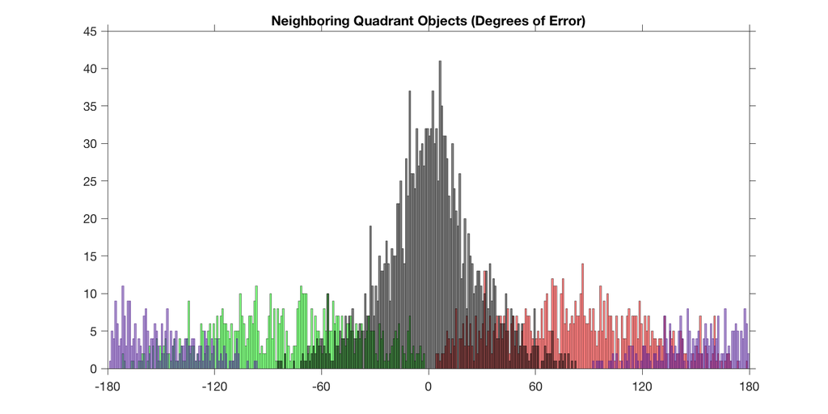

```matlab
openfig('ColorGraph_NQs.fig');
```

It seems people did a lot better at the task now that we used a blocked design.

We can eyeball that there appears to be more red responses than green responses, meaning more responses in the rich quadrant than the far quadrant.

Here is a close-up comparing the green histogram and the red histogram.

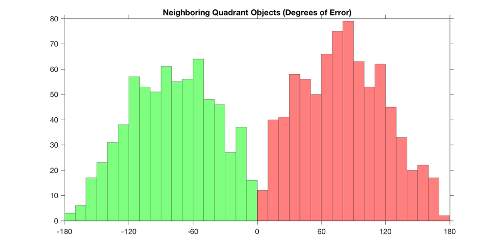

```matlab
openfig('ColorGraph_NQs_4.fig');
```

And now overlaying the two, by adding 180 to the green histogram and flipping it horizontally:

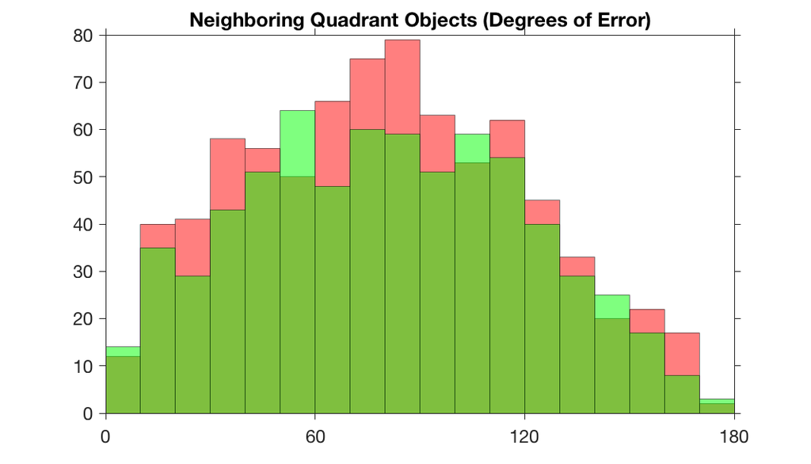

```matlab
openfig('ColorGraph_NQs_5.fig');
```

For the above histogram:

Red responses = 773; Green responses = 672.

Doing a simple towards vs away t-test was not significant (avg. 51% of responses were "towards", p = .34). Specifically, for each subject, I divided their number of "towards" by their number of "towards" + "away" responses, and compared to a null of 0.5.

Doing a simple towards vs away t-test among "non-black histogram" responses (aka responses in the incorrect quadrant), was not significant (avg. 53% of responses were "towards", p=.17).

Doing a simple towards vs away t-test among only the red/green histogram responses (aka responses in the incorrect quadrant, excluding wrong neighboring quadrant responses), was marginally significant (avg. 55% of responses were "towards", p=.07).

Here is the first histogram again with all the colors, but this time with a transparent blue histogram overlaid on top.

This blue histogram represents the simple overall histogram. That is, the blue histogram puts the green, red, purple, and black histograms all together.

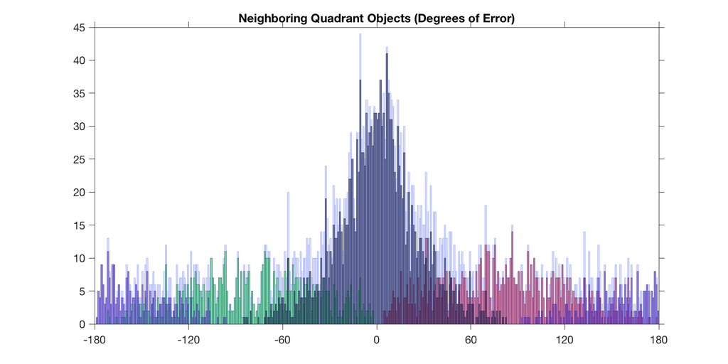

```matlab
openfig('ColorGraph_NQs_2.fig');
```

Now showing the blue histogram without any of the other histograms:

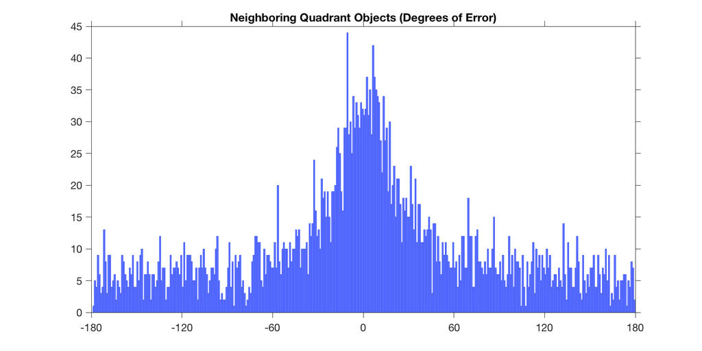

```matlab
openfig('ColorGraph_NQs_3.fig');
title('Neighboring Quadrant Objects (Degrees of Error)')
```

Number of towards responses = 1835; Number of away responses = 1736.

As you can see, without color coding, the RQ swapping errors become even more difficult to see.

Which is why, when using probabilistic mixture modeling in MemToolbox, we get no obvious bump on the right side (changing the number of bins doesn't help much):

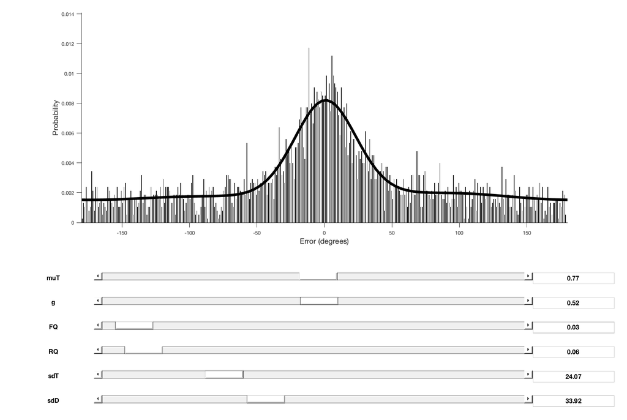

```matlab
openfig('NQs_INCCOLLAPSED11.fig');
```

However, averaging across included subject model fits, there is a significant difference between RQ and FQ proportions.

Here is a visual depiction of each individual's RQprop minus their FQprop, with error bar representing SEM:

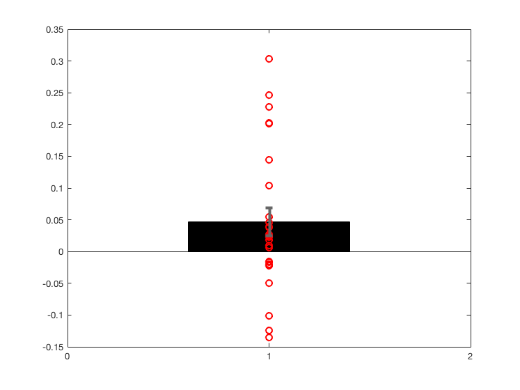

```matlab
openfig('RQpropVSFQprop_NQs.fig');
```

A paired sample t-test between RQprop and FQprop was significant (p=0.046).

Here are the average model fits for NQs data:

- Target Proportion: .44 (SEM: .04)
- Target SD: 30.89 deg. (SEM: 3.71 deg.)
- Guessing Proportion: .36 (SEM: .04)
- RQ Proportion: .126 (SEM: .02)
- FQ Proportion: .079 (SEM: .02)
- Biased SD: 56.28 deg. (SEM: 5.36 deg.)
- Mean Shift: -2.19 (SEM: 2.51, not significant)

I am unsure why the collapsed subjects RQprop is .06 whereas averaging across individual fits yields .13.

I also repeated these analyses when including the Far Quadrant:

# Non-Rich Quadrant Data

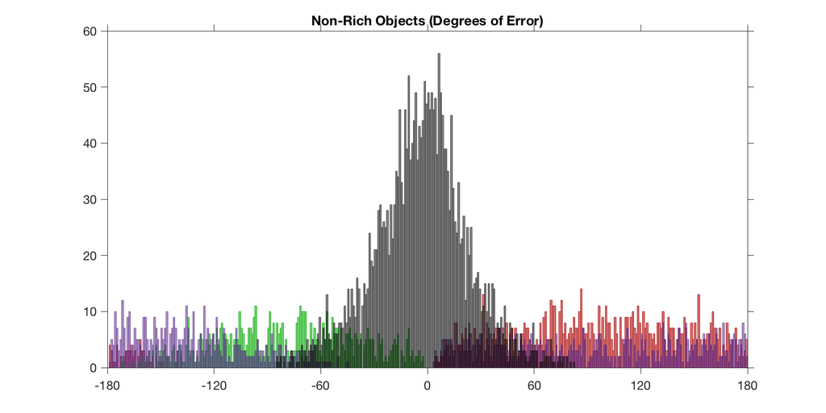

```matlab
openfig('ColorGraph_noRQ.fig');
```

When I first saw this graph I was like oh wow look at how much bigger that red hump looks compared to the green hump! Unfortunately, this is not due to swapping errors.

For instance, here is the far quadrant by itself:

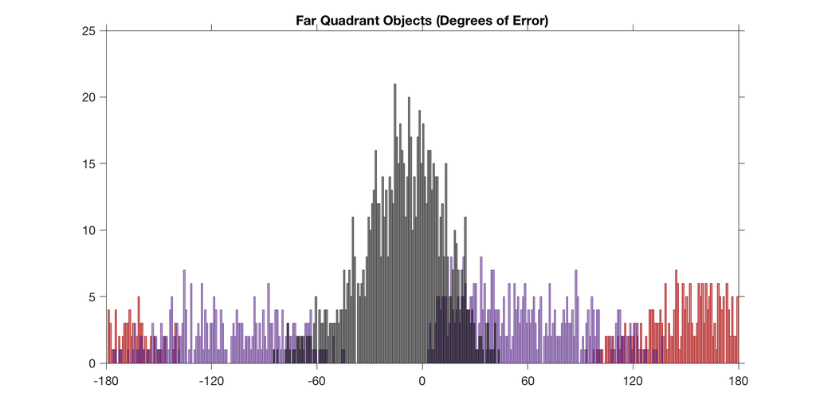

```matlab
openfig('ColorGraph_FQ.fig');
```

As you can see, there is no green hump, because all of the green hump gets encompassed in the black (correct quadrant) histogram. Therefore, this color method is misleading when including the far quadrant (that's why I discussed neighboring quadrant objects only first).

A bit of a tangent, but you'll see there are some red responses that are negative. This is because of a few fringe cases. For instance, imagine that RQ is centered at 0 degrees, and that the FQ is centered at 180 degrees. Let's imagine that the test trial was a FQ object, and the original color for it was at 200 deg. Therefore, any response between 20 and 200 would be classified as "away" and any response greater than 200 and less than 20 would be classified "towards". (Towards meaning towards the center of the RQ)

If the person reported at 30 deg., this would be included within the rich quadrant and yet still be labeled as "away".

Here is a (bad) graphical depiction:

[figure not shown]

For completeness, here is the overall histogram for nonRQ objects:

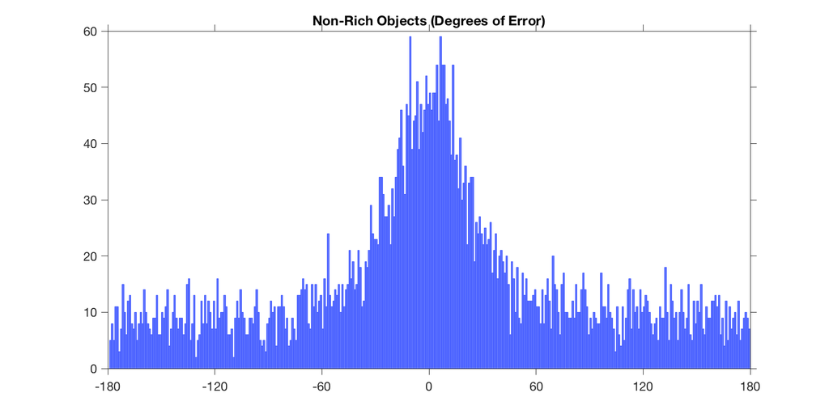

```matlab
openfig('ColorGraph_noRQ_3.fig');
```

For the above histogram:

Towards responses = 2847; Away responses = 2720.

All towards/away analyses were not significant.

For the probabilistic mixture model:

### Collapsed:

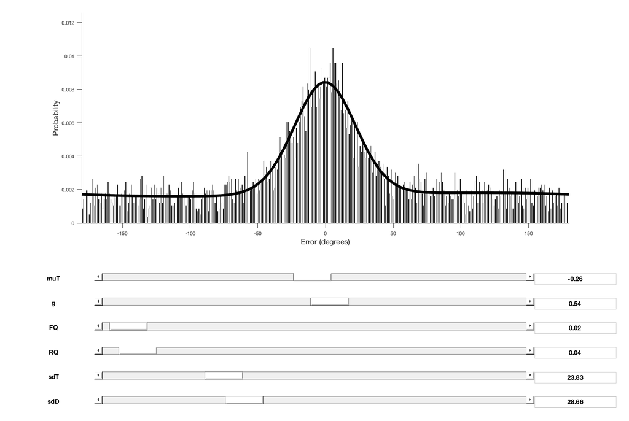

```matlab
openfig('noRQ_INCCOLLAPSED11.fig');
```

### Individual RQprop-FQprop:

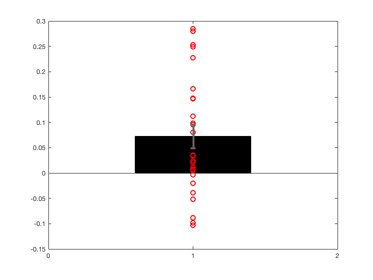

```matlab
openfig('RQpropVSFQprop.fig');
```

7/26 subjects showed RQprop < FQprop. 12/26 subjects showed RQprop-FQprop > 0.05.

A paired sample t-test between RQprop and FQprop was significant (p<.01).

Here are the average model fits for nonRQ data:

- Target Proportion: .43 (SEM: .04)
- Target SD: 27.44 deg. (SEM: 2.45 deg.)
- Guessing Proportion: .39 (SEM: .05)
- RQ Proportion: .124 (SEM: .02)
- FQ Proportion: .053 (SEM: .02)
- Biased SD: 55.18 deg. (SEM: 5.34 deg.)
- Mean Shift: -1.53 (SEM: 1.88, not significant)

Again, I am unsure why the collapsed subjects RQprop is so much lower than the RQprop averaged across fits.

# Rich Quadrant Data

Here is the collapsed subjects overall histogram:

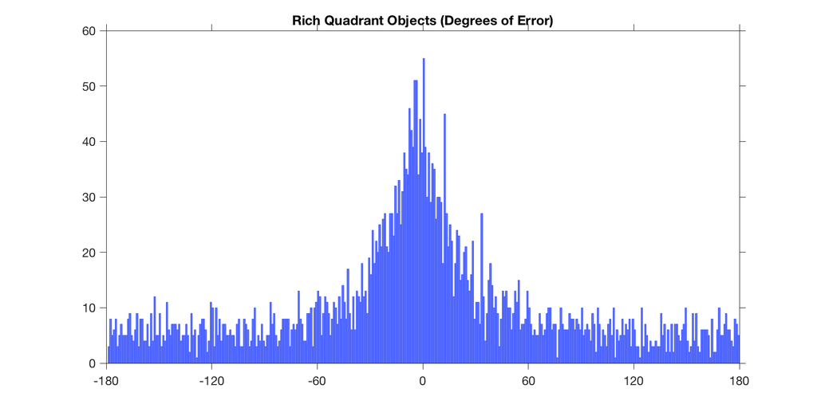

```matlab
openfig('ColorGraph_RQ_3.fig');
```

Towards responses: 1720; Away responses: 1969

Doing a simple towards vs away t-test **was** significant (avg. 46.6% of responses were "towards", p = .02).

Surprisingly, there is a repulsion effect away from the center of the rich quadrant.

Here is the collapsed subject model fit:

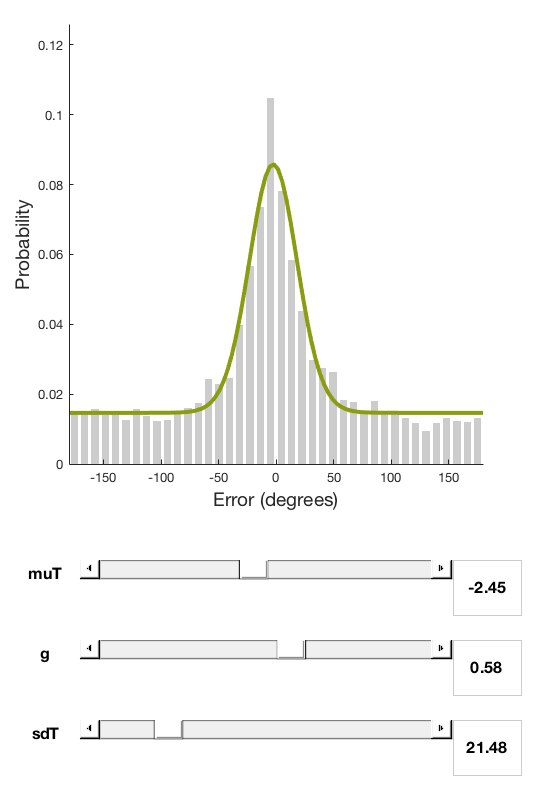

```matlab
openfig('RQ_SMM_INCCOLLAPSED11');
```

Here are the average model fits for RQ data:

- Target Proportion: .47 (SEM: .05)
- Target SD: 23.46 deg. (SEM: 2.58 deg.)
- Guessing Proportion: .53 (SEM: .05)
- Mean Shift: -4.39 (SEM: 1.8, p=.02)

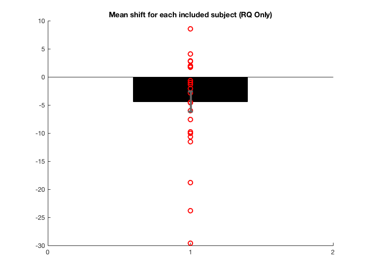

```matlab
cd '/Users/scotti.5/Dropbox/Shared Lab Folder/Experiments/Contextual_LTM/mTurk Analysis/figs'
openfig('meanm2_bar.fig');
title('Mean shift for each included subject (RQ Only)')
```

I then wondered if there is perhaps also a mean shift if I applied the same standard mixture model to the nonRQ data. The answer to that is no.

# Post-Experiment Data

- 6/26 subjects selected yes to the nonrandom color sampling question, answered >3 on Likert rating (1-6), AND clicked within the RQ. So this was largely an implicit task. When I exclude these subjects from the dataset, all the above significant results remain significant.

Here are some extra graphs for the included subjects. I didn't really get much out of them but you can see for yourself:

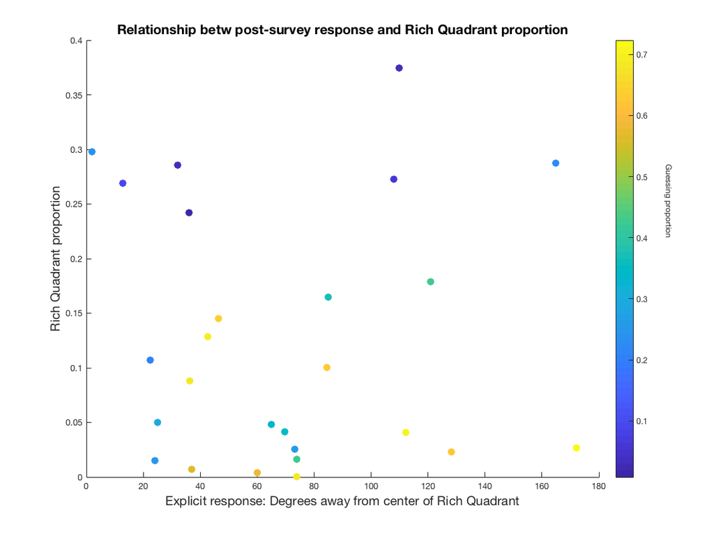

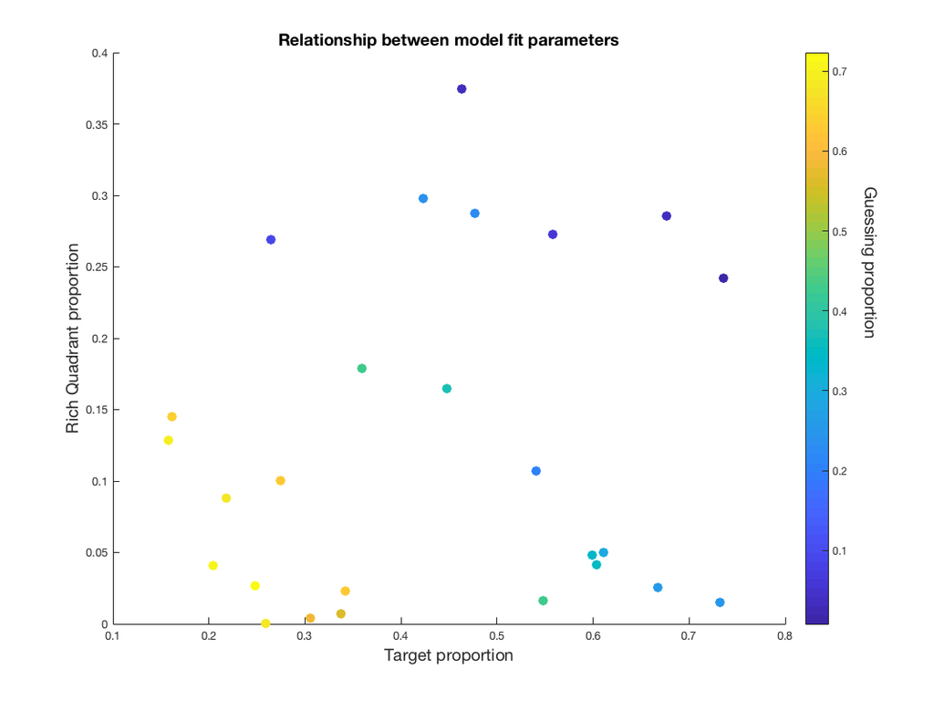

```matlab
openfig('postFig_1.fig');
openfig('postFig_2.fig');
```

# Confidence Reports

I didn't model each individual's data according to median split yet, but I did do the basic towards/away analyses. Basically for every subject I only took trials that were above their median confidence interval length (and vice versa). For nonRQ objects, nothing of interest came up. For RQ objects, towards vs. away analysis was significant in both cases. That is, for high confidence (p=.04) and low confidence (p=.02).

# Individual Model Fits (Included Subjects, non-RQ data)

Some of the plots look different from the others because if one didnt converge the first try, I retried it on another day, which typically worked, but I was playing around with the visualizations for MemToolbox in the meantime.

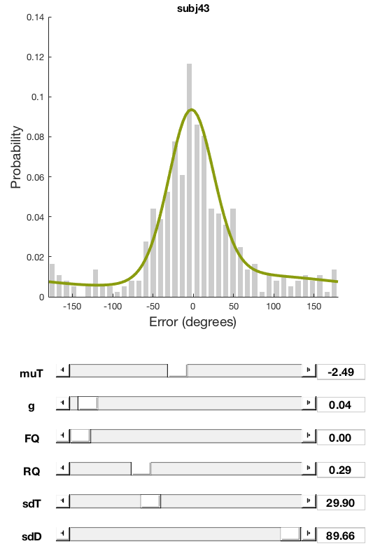

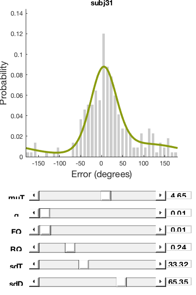

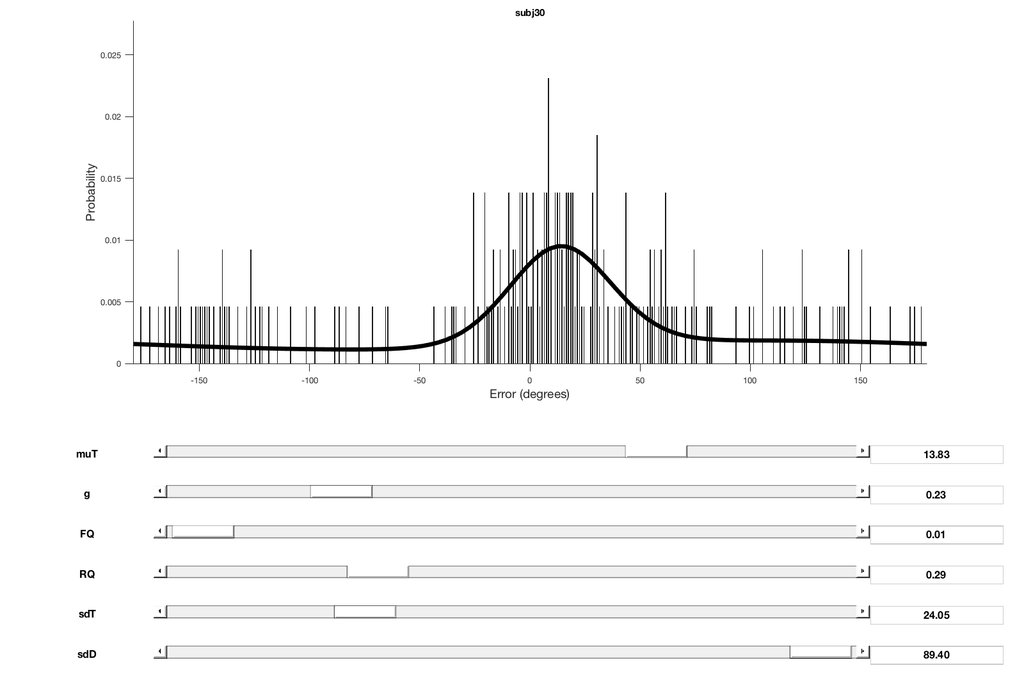

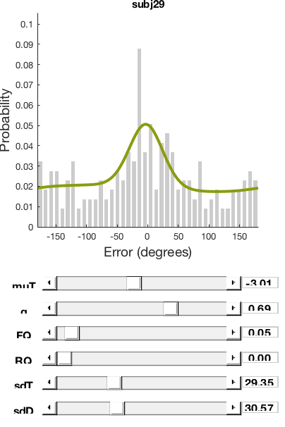

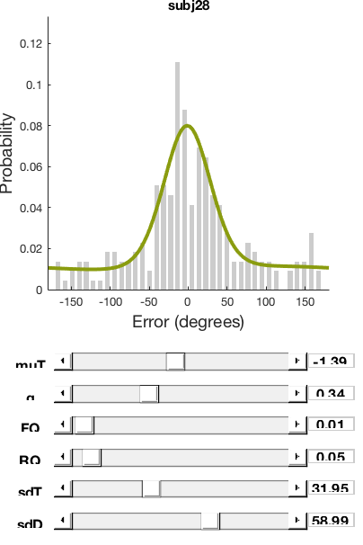

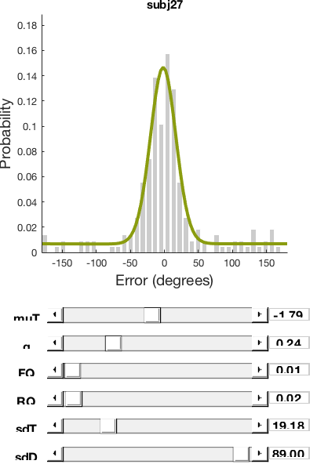

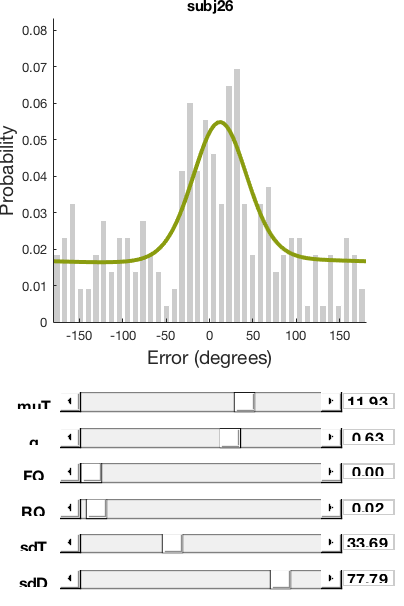

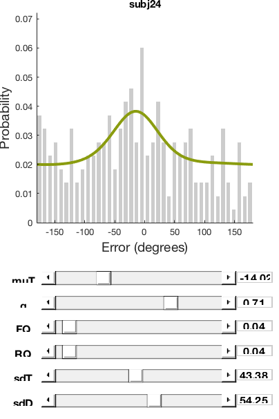

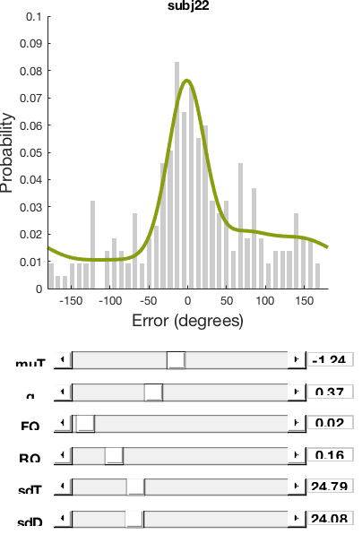

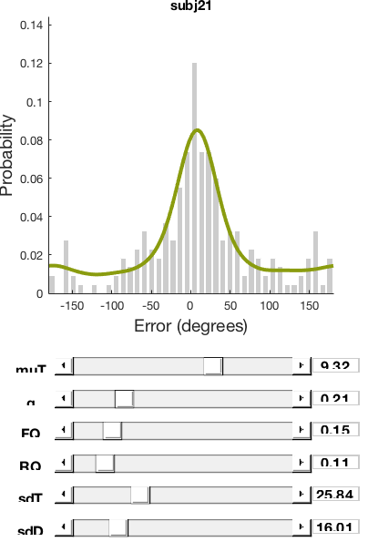

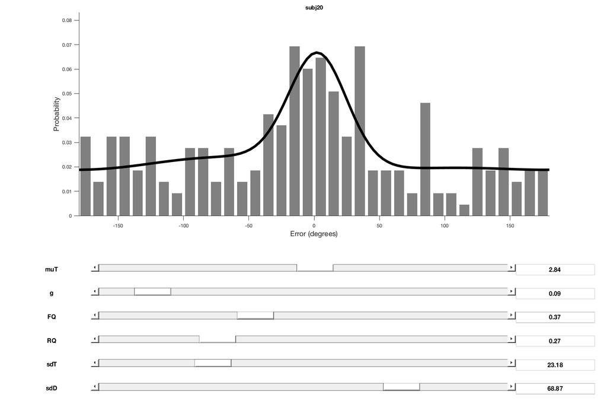

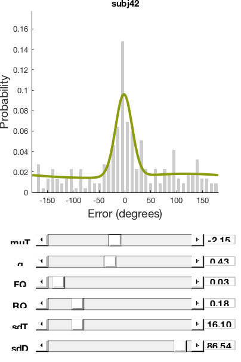

[13 more figures not shown]

```matlab
openfig('noRQ_subj11.fig');
title('subj11');
openfig('noRQ_subj12.fig');
title('subj12');
openfig('noRQ_subj14.fig');
title('subj14');
openfig('noRQ_subj15.fig');
title('subj15');
openfig('noRQ_subj17.fig');
title('subj17');
openfig('noRQ_subj19.fig');
title('subj19');
openfig('noRQ_subj20.fig');
title('subj20');
openfig('noRQ_subj21.fig');
title('subj21');
openfig('noRQ_subj22.fig');
title('subj22');
openfig('noRQ_subj24.fig');
title('subj24');
openfig('noRQ_subj26.fig');
title('subj26');
openfig('noRQ_subj27.fig');
title('subj27');
openfig('noRQ_subj28.fig');
title('subj28');
openfig('noRQ_subj29.fig');
title('subj29');
openfig('noRQ_subj30.fig');
title('subj30');
openfig('noRQ_subj31.fig');
title('subj31');
openfig('noRQ_subj32.fig');
title('subj32');
openfig('noRQ_subj33.fig');
title('subj33');
openfig('noRQ_subj35.fig');
title('subj35');
openfig('noRQ_subj36.fig');
title('subj36');
openfig('noRQ_subj37.fig');
title('subj37');
openfig('noRQ_subj39.fig');
title('subj39');
openfig('noRQ_subj41.fig');
title('subj41');
openfig('noRQ_subj42.fig');
title('subj42');
openfig('noRQ_subj43.fig');
title('subj43');
```